# Assignment 4

## Q1

How many particles labeled “synecho” are in the file provided?

```r
length(which(seaflow_21min$pop == "synecho"))
```

```
## [1] 18146
```

## Q2

What is the 3rd Quantile of the field fsc_small?

```r
summary(seaflow_21min)
```

```
##     file_id           time          cell_id            d1
##  Min.   :203.0   Min.   : 12.0   Min.   :    0   Min.   : 1328
##  1st Qu.:204.0   1st Qu.:174.0   1st Qu.: 7486   1st Qu.: 7296
##  Median :206.0   Median :362.0   Median :14995   Median :17728
##  Mean   :206.2   Mean   :341.5   Mean   :15008   Mean   :17039
##  3rd Qu.:208.0   3rd Qu.:503.0   3rd Qu.:22401   3rd Qu.:24512
##  Max.   :209.0   Max.   :643.0   Max.   :32081   Max.   :54048
##        d2          fsc_small        fsc_perp        fsc_big
##  Min.   :   32   Min.   :10005   Min.   :    0   Min.   :32384
##  1st Qu.: 9584   1st Qu.:31341   1st Qu.:13496   1st Qu.:32400
##  Median :18512   Median :35483   Median :18069   Median :32400
##  Mean   :17437   Mean   :34919   Mean   :17646   Mean   :32405
##  3rd Qu.:24656   3rd Qu.:39184   3rd Qu.:22243   3rd Qu.:32416
##  Max.   :54688   Max.   :65424   Max.   :63456   Max.   :32464
##        pe          chl_small        chl_big           pop
##  Min.   :    0   Min.   : 3485   Min.   :    0   crypto :  102
##  1st Qu.: 1635   1st Qu.:22525   1st Qu.: 2800   nano   :12698
##  Median : 2421   Median :30512   Median : 7744   pico   :20860
##  Mean   : 5325   Mean   :30164   Mean   : 8328   synecho:18146
##  3rd Qu.: 5854   3rd Qu.:38299   3rd Qu.:12880   ultra  :20537
##  Max.   :58675   Max.   :64832   Max.   :57184
```

## Q3

Divide the data into two equal subsets, one for training and one for testing. Make sure to divide the data in an unbiased manner.

What is the mean of the variable “time” for your training set?

```r
## 50% of the sample size
smp_size <- floor(0.5 * nrow(seaflow_21min))

## set the seed to make your partition reproductible
set.seed(123)
train_ind <- sample(seq_len(nrow(seaflow_21min)), size = smp_size)

train <- seaflow_21min[train_ind, ]
test <- seaflow_21min[-train_ind, ]

mean(train$time)
```

```
## [1] 341.1094
```

## Q4

In the plot of pe vs. chl_small, the particles labeled ultra should appear to be somewhat “mixed” with two other populations of particles. Which two populations?

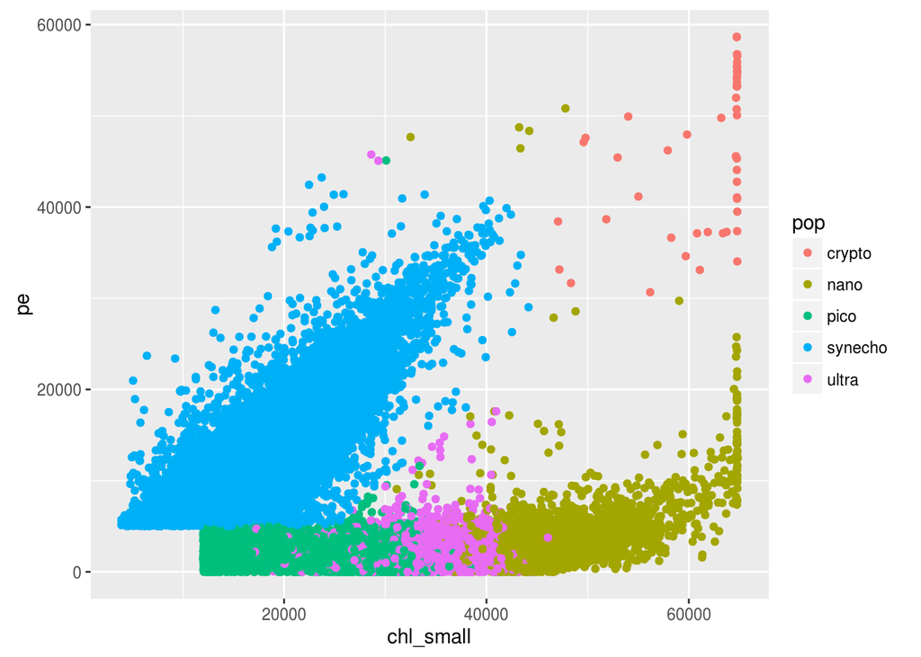

```r
ggplot(data = train, aes(x = chl_small, y = pe)) +
  geom_point(aes(colour = pop))
```

## Q5

Train a tree as a function of the sensor measurements

Use print(model) to inspect your tree. Which populations, if any, is your tree incapable of recognizing?

```r
fol <- formula(pop ~ fsc_small + fsc_perp + fsc_big + pe + chl_big + chl_small) #formula object
model <- rpart(fol, method="class", data=train) #Train model
print(model)
```

```
## n= 36171
##
## node), split, n, loss, yval, (yprob)
##       * denotes terminal node
##
##  1) root 36171 25730 pico (0.0013 0.18 0.29 0.25 0.28)
##    2) pe< 5004 26314 15923 pico (0 0.22 0.39 3.8e-05 0.38)
##      4) chl_small< 32652 11923  2256 pico (0 0.00042 0.81 8.4e-05 0.19) *
##      5) chl_small>=32652 14391  6618 ultra (0 0.41 0.05 0 0.54)
##       10) chl_small>=41300 5242   653 nano (0 0.88 0.00019 0 0.12) *
##       11) chl_small< 41300 9149  2028 ultra (0 0.14 0.079 0 0.78) *
##    3) pe>=5004 9857   773 synecho (0.0048 0.055 0.0051 0.92 0.014)
##      6) chl_small>=38881.5 637   114 nano (0.074 0.82 0 0.049 0.057) *
##      7) chl_small< 38881.5 9220   167 synecho (0 0.002 0.0054 0.98 0.011) *
```

## Q6

Most trees will include a node near the root that applies a rule to the pe field, where particles with a value less than some threshold will descend down one branch, and particles with a value greater than some threshold will descend down a different branch.

If you look at the plot you created previously, you can verify that the threshold used in the tree is evident visually.

What is the value of the threshold on the pe field learned in your model?

## Q7

Based on your decision tree, which variables appear to be most important in predicting the class population?

## Q8

How accurate was your decision tree on the test data?

```r
pred <- predict(model, newdata=test, type = "class")
#confusionMatrix(pred, test$pop)
sum(pred == test$pop)/nrow(test)
```

```
## [1] 0.853699
```

## Q9

What was the accuracy of your random forest model on the test data?

```r
modelrf <- randomForest(fol, method = "class", data = train)
predrf <- predict(modelrf, newdata = test)
sum(predrf == test$pop)/nrow(test)
```

```
## [1] 0.9210439
```

## Q10

A random forest can obtain another estimate of variable importance based on the Gini impurity that we discussed in the lecture. The function importance(model) prints the mean decrease in gini importance for each variable. The higher the number, the more the gini impurity score decreases by branching on this variable, indicating that the variable is more important

```r
importance(modelrf)
```

```
##           MeanDecreaseGini
## fsc_small        2759.9395
## fsc_perp         2079.9317
## fsc_big           202.0581
## pe               8959.8966
## chl_big          4906.6215
## chl_small        7963.2238
```

## Q11

Train a support vector machine model and compare results.

Use the e1071 library and call model <- svm(fol, data=trainingdata)

```r
modele <- svm(fol, data=train)
prede <- predict(modele, newdata = test)
sum(prede == test$pop)/nrow(test)
```

```
## [1] 0.9202975
```

## Q12

Use the table function to generate a confusion matrix for each of your three methods.

What appears to be the most common error the models make?

```r
#table(pred = , true = test$pop) #Doesn't work
print(modelrf)
```

```
##
## Call:
##  randomForest(formula = fol, data = train, method = "class")
##                Type of random forest: classification
##                      Number of trees: 500
## No. of variables tried at each split: 2
##
##         OOB estimate of  error rate: 8%
## Confusion matrix:
##         crypto nano  pico synecho ultra  class.error
## crypto      46    0     0       1     0 0.0212765957
## nano         2 5620     0       2   816 0.1273291925
## pico         0    0 10080      13   348 0.0345752323
## synecho      0    3     0    9081     1 0.0004402862
## ultra        0  351  1350       6  8451 0.1680448907
```

## Q13

The variables in the dataset were assumed to be continuous, but one of them takes on only a few discrete values, suggesting a problem. Which variable exhibits this problem?

fsc_big

## Q14

There is more subtle issue with data as well. Plot time vs. chl_big, and you will notice a band of the data looks out of place. This band corresponds to data from a particular file for which the sensor may have been miscalibrated. Remove this data from the dataset by filtering out all data associated with file_id 208, then repeat the experiment for all three methods, making sure to split the dataset into training and test sets after filtering out the bad data.

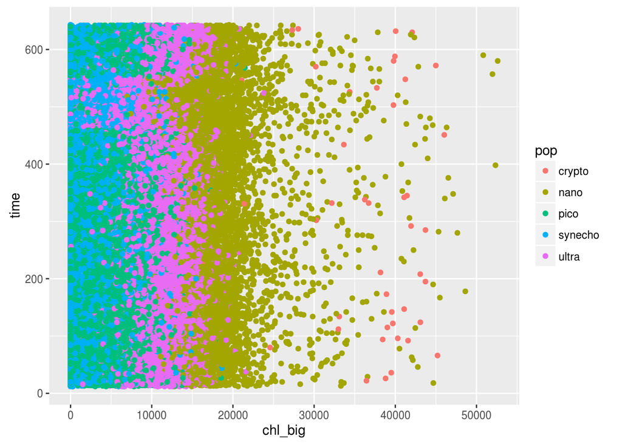

```r
ggplot(data = train, aes(x = chl_big, y = time)) +
  geom_point(aes(colour = pop))
```

```r
#Remove data with file_id 208
removed <- seaflow_21min[! (seaflow_21min$file_id == 208), ]
#Repeat SVM modeling
## 50% of the sample size
smp_sizer <- floor(0.5 * nrow(removed))

## set the seed to make your partition reproductible
set.seed(123)
train_indr <- sample(seq_len(nrow(removed)), size = smp_sizer)

trainr <- removed[train_indr, ]
testr <- removed[-train_indr, ]
modelrepeat <- svm(fol, data=trainr)
predrep <- predict(modelrepeat, newdata = testr)
sum(predrep == testr$pop)/nrow(testr)
```

```
## [1] 0.9710347
```